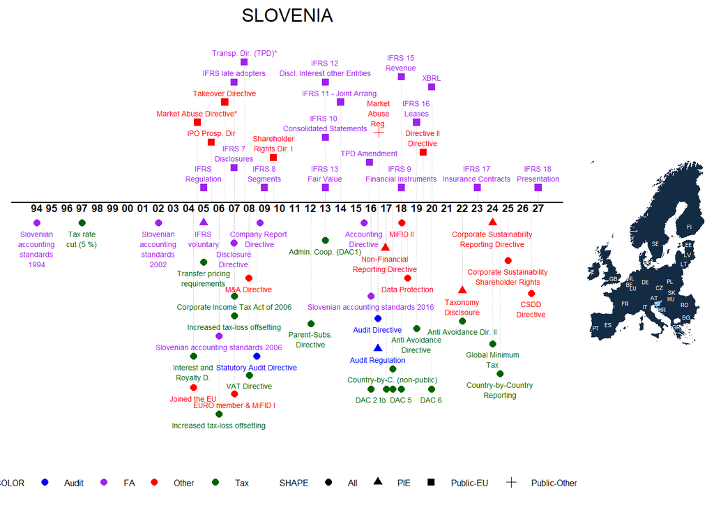

Notes: The graph depicts major regulatory changes that we identified via an extensive literature search, an online survey of mentioned authors, and other sources. Please note that the graph does not include all possible regulatory changes, e.g. minor revisions to local GAAP or tax rate changes below 3% are not included. The dates of EU Directives are based on the official transposition deadlines unless denoted with a *, in which case we included the entry-to-force date as identified in the literature. For more information, please go to [Labro and Pierk (2025)](https://link.springer.com/article/10.1007/s11142-025-09909-0). We kindly ask that you cite the paper if you use the information on this website in your research project. Do you have comments or see anything missing? Please email us!

## Regulations, Publications, Further Graphs

The tab ‘Regulations’ includes links to the regulations, gives short descriptions, and provides selective papers for further reading. If the regulation is a national transposition of an EU Directive, the link to the Directive is given. The tab ‘Number of Regulations’ shows graphically the number of regulations 8 years around the respective year (-4,-3,-2,-1,0,+1,+2,+3). The tab ‘Number of Categories” shows graphically the number of different categories 8 years around the respective year (-4,-3,-2,-1,0,+1,+2,+3). The tab ’Publications’ shows all publications that include the countries’ names and variations thereof in the title, abstract, or keywords. Similarly, the tab ‘SSRN’ shows papers of the SSRN Accouning Research Network that include the countries’ names and variations.

### Regulations

[output not shown]

[output cut: 53 more lines]

### Number of Regulations

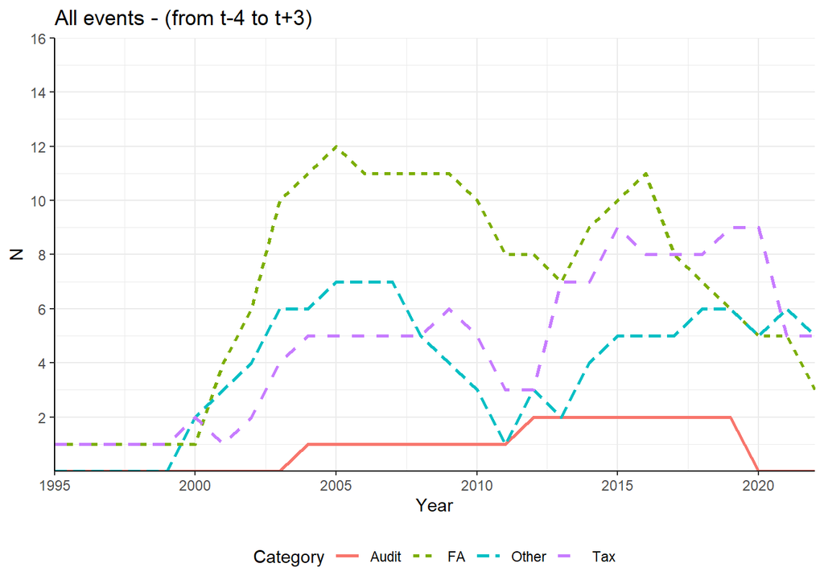

### Number of Categories

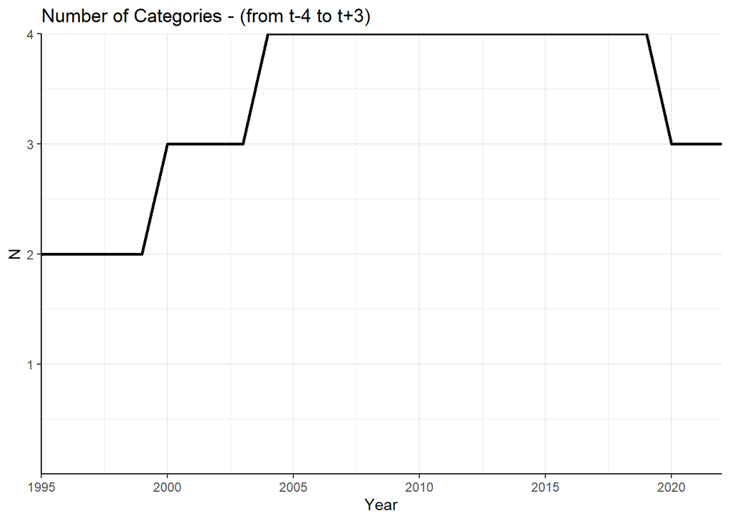

### Publications

|  | authors | title | year | journal |
| --- | --- | --- | --- | --- |
| 1 | Cadez S., Guilding C. | examining distinct carbon cost structures and climate change abatement strategies in co2 polluting firms | 2017 | Accounting, Auditing and Accountability Journal |
| 2 | Novak A., Valentinčič A. | the role and current status of ifrs in the completion of national accounting rules–evidence from slovenia | 2017 | Accounting in Europe |
| 3 | Valentincic A., Novak A., Kosi U. | accounting quality in private firms during the transition towards international standards | 2017 | Accounting in Europe |
| 4 | Duhovnik M. | time to endorse the isas for european use: the emerging markets' perspective | 2011 | Accounting in Europe |
| 5 | Groff M.Z., Valentinčič A. | determinants of voluntary audit committee formation in a two-tier board system of a post-transitional economy - the case of slovenia | 2011 | Accounting in Europe |
| 6 | Cadez S., Guilding C. | an exploratory investigation of an integrated contingency model of strategic management accounting | 2008 | Accounting, Organizations and Society |
| 7 | Bonsón E., Escobar T. | digital reporting in eastern europe: an empirical study | 2006 | International Journal of Accounting Information Systems |
| 8 | Spremic M., Strugar I. | strategic is planning practise in croatia: organizational and managerial challenges | 2002 | International Journal of Accounting Information Systems |
| 9 | Garrod N., Turk I. | the development of accounting regulation in slovenia | 1995 | European Accounting Review |

### SSRN

|  | authors | title | Posted | Revised |
| --- | --- | --- | --- | --- |
| 1 | Horst Treiblmaier | will blockchain really impact your business model? empirical evidence from slovenian smes | 2021-11-23 |  |
| 2 | Tim Sovaniski | assessment the internal control system of banks | 2021-03-11 |  |